# Analyzing Land Use and Fires in California

I am from the Sierra Nevada and Lake Tahoe area, so I am particularly interested in how fires are affecting different ecosystems and land uses. I thought exploring fire data more closely would be a good exercise for learning Python and how to extract/transform/load data using the ArcGIS API for Python, Arcpy, and Pandas libraries, conducting various tabular and spatial analyses, plotting and graphing results, and illustrating key findings.

🔥💻🏡

```python
# Import and connect to GIS
import pandas as pd
import numpy as np
import matplotlib.pyplot as plt
from arcgis.gis import GIS
from PIL import Image
import PIL.ImageOps
from IPython.display import display
Image.MAX_IMAGE_PIXELS = None
import warnings
warnings.filterwarnings('ignore') # Ignore warnings

gis = GIS('Pro')
```

The first step in my analysis is to find fire data for California. We can use the ArcGIS API for Python to search and find relevant layers, and then map them interactively in a map widget.

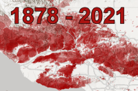

[**California Fire Perimeters 1878 - 2021**](https://www.arcgis.com//home/item.html?id=6fd0d8d6f47d414da7bcb1dcd0539999)  
This layer contains the fire perimeters from the previous calendar year, and those dating back to 1878, for California. Perimeters are sourced from the Fire and Resource Assessment Program (FRAP) and are updated after the end of each calendar year.

[figure not shown]

Feature Layer Collection by juliah_esri  
Last Modified: January 10, 2023  
5 comments, 9,590,685 views

```python
search = gis.content.search("title:CAL FIRE California Fire Perimeters (All to 2021)", outside_org=True) # search for fire data!
fires_collection = search[0] # pull out the first search result"
fires = fires_collection.layers[1] # there are three layers, the second layer has "burn areas" which is what we want

fires_collection
```

```python
fire_map = gis.map("California", zoomlevel = 4) # instantiate a map object and center it on California
fire_map.basemap = 'gray-vector' # set up a gray basemap to contrast with the red polygons
fire_map.add_layer(fires) # add the fires layer from above to the map
fire_map.legend = True # add a legend
fire_map # plot!
```

[figure not shown]

We will want to look at the fire data closely, inspecting various attributes and elements (and eventually convert it to a raster dataset!). In order to work with this data in a tabular format, I turned it into a Spatial DataFrame in Pandas:

```python
sdf_fires = pd.DataFrame.spatial.from_layer(fires) # create a spatial data frame
sdf_fires = sdf_fires.drop(columns = ["COMMENTS", "C_METHOD", "CONT_DATE", "FIRE_NUM", # we don't need these columns!
                                      "INC_NUM", "OBJECTIVE", "REPORT_AC", "UNIT_ID"])
sdf_fires.sample(3) # I prefer to take a sample rather than the head or tail because we can find anomalies!
```

|  | AGENCY | ALARM_DATE | CAUSE | FIRE_NAME | GIS_ACRES | GlobalID | OBJECTID | SHAPE | STATE | Shape__Area | Shape__Length | YEAR_ |
| --- | --- | --- | --- | --- | --- | --- | --- | --- | --- | --- | --- | --- |
| 703 | CDF | 2007-04-09 | 5.0 | WILSON | 10.57157 | 411c8b16-3acd-4cc6-84c7-e95a558bccf3 | 22155 | {"rings": [[[-106373.091400001, 110041.4543999... | CA | 42781.634991 | 938.355808 | 2007 |
| 14330 | CDF | 2002-08-11 | 10.0 | GREENSTONE | 16.24566 | 680acb83-2fcc-427d-a18d-b30e718c36a8 | 35799 | {"rings": [[[-76023.2789999992, 76103.20869999... | CA | 65743.867067 | 1111.199212 | 2002 |
| 15728 | USF | 1987-08-30 | 1.0 | MORMON | 26.97684 | d9b98efa-2a84-47df-a0c7-0e61360a5f55 | 37197 | {"rings": [[[52093.010400001, -87441.451099999... | CA | 109171.411863 | 1605.190569 | 1987 |

There is a column for "years", let's see what the range is for that column.

```python
sdf_fires['YEAR_'].replace('', np.nan, inplace=True) # replace all the empty values with nulls
sdf_fires.dropna(axis = 0, subset = ['YEAR_']).sort_values('YEAR_') # drop the nulls and sort by year
```

|  | AGENCY | ALARM_DATE | CAUSE | FIRE_NAME | GIS_ACRES | GlobalID | OBJECTID | SHAPE | STATE | Shape__Area | Shape__Length | YEAR_ |
| --- | --- | --- | --- | --- | --- | --- | --- | --- | --- | --- | --- | --- |
| 2563 | CCO | NaT | 14.0 |  | 59468.880000 | e2f56f11-3616-4c38-8dfb-8d6abc1e8ae6 | 24017 | {"rings": [[[177636.099300001, -401927.5648], ... | CA | 2.406620e+08 | 8.795202e+04 | 1878 |
| 2567 | CCO | NaT | 14.0 |  | 628.113600 | 84227cda-2775-4b99-9573-04e4f809ccf2 | 24021 | {"rings": [[[176744.139699999, -420594.8196], ... | CA | 2.541886e+06 | 5.928650e+03 | 1895 |
| 2568 | CCO | NaT | 14.0 |  | 7531.717000 | 82de5d05-2824-4e76-afaf-40b3a4295710 | 24022 | {"rings": [[[176212.638099998, -413114.4545], ... | CA | 3.047978e+07 | 3.016682e+04 | 1896 |
| 2571 | CCO | 1898-09-01 00:00:00 | 14.0 | LOS PADRES | 20539.950000 | 959f1e66-1ce2-4d57-9eee-7401a35cd811 | 24025 | {"rings": [[[60673.8936999999, -393541.582], [... | CA | 8.312223e+07 | 4.619133e+04 | 1898 |
| 2570 | CCO | NaT | 14.0 |  | 428.438700 | 33f47dd3-1e5b-4f15-8087-fc152e7f7cc5 | 24024 | {"rings": [[[190032.8268, -407135.4015], [1899... | CA | 1.733830e+06 | 4.996834e+03 | 1898 |
| ... | ... | ... | ... | ... | ... | ... | ... | ... | ... | ... | ... | ... |
| 21427 | LRA | 2021-06-11 00:00:00 | 2.0 | SMITH | 9.446896 | 99d88885-71b8-4f0b-9591-fe8c9bf9d098 | 42921 | {"rings": [[[-186281.5998, 224274.9837], [-186... | CA | 3.823023e+04 | 1.011835e+03 | 2021 |
| 21426 | NPS | 2021-07-01 00:00:00 | 1.0 | COUNTY LINE | 224.926500 | 5a91e353-12eb-4b80-8821-efee1c83ca2a | 42920 | {"rings": [[[31560.5238000005, -17668.75679999... | CA | 9.102454e+05 | 5.265824e+03 | 2021 |
| 21425 | NPS | 2021-07-10 00:00:00 | 1.0 | LOST | 100.782400 | 2146824b-8736-4c76-99ee-96834859b067 | 42919 | {"rings": [[[115823.077399999, -121002.206], [... | CA | 4.078521e+05 | 5.788054e+03 | 2021 |
| 21434 | NPS | 2021-09-10 00:00:00 | 1.0 | KNP Complex | 88257.130000 | 99ef4f9c-67e9-480c-98fa-13f6ca8aaec1 | 42928 | {"rings": [[[111754.832800001, -175863.8829], ... | CA | 3.571639e+08 | 3.936929e+05 | 2021 |
| 21685 | USF | 2021-07-31 21:20:01 | 1.0 | RIVER COMPLEX | 199354.100000 | 6808210b-3441-41b6-9d87-5f2d4de837ca | 43183 | {"rings": [[[-259575.0404, 330786.0592], [-259... | CA | 8.067574e+08 | 1.216645e+06 | 2021 |

21609 rows × 12 columns

```python
sdf_fires_2011 = sdf_fires.query("YEAR_ == '2011'") # just look at 2011 fires
sdf_fires_2011.sample(3)
```

|  | AGENCY | ALARM_DATE | CAUSE | FIRE_NAME | GIS_ACRES | GlobalID | OBJECTID | SHAPE | STATE | Shape__Area | Shape__Length | YEAR_ |
| --- | --- | --- | --- | --- | --- | --- | --- | --- | --- | --- | --- | --- |
| 17469 | CCO | 2011-07-02 | 14.0 | CHARLIE | 80.12396 | 408dc512-e20a-4749-a23e-89f659ae3366 | 38943 | {"rings": [[[141477.725499999, -357405.3252], ... | CA | 3.242502e+05 | 3465.228758 | 2011 |
| 17410 | BLM | 2011-09-24 | 9.0 | WINDY POINT | 541.49620 | a3e91b36-4a3e-4bc3-9121-f89c62d0134f | 38884 | {"rings": [[[315975.276799999, -454920.5668], ... | CA | 2.191357e+06 | 6789.588613 | 2011 |
| 17617 | CDF | 2011-08-14 | 14.0 | BRIDGE | 77.20834 | e61c1176-ecba-472b-8dcc-b2a93e75af7e | 39091 | {"rings": [[[-58110.7575999983, -20961.1687000... | CA | 3.124511e+05 | 2686.832819 | 2011 |

Let's start by asking a very simple question. What was the largest fire in 2011 (by acres burned)?

```python
sdf_fires_2011.sort_values('GIS_ACRES', ascending = False)[:1] # sort descending and select the first row
```

|  | AGENCY | ALARM_DATE | CAUSE | FIRE_NAME | GIS_ACRES | GlobalID | OBJECTID | SHAPE | STATE | Shape__Area | Shape__Length | YEAR_ |
| --- | --- | --- | --- | --- | --- | --- | --- | --- | --- | --- | --- | --- |
| 17453 | CCO | 2011-09-10 | 1.0 | COMANCHE | 25939.01 | 30871627-ee18-4315-bd85-97e5ec0dc80b | 38927 | {"rings": [[[112929.477899998, -313801.638], [... | CA | 1.049715e+08 | 67464.656787 | 2011 |

The Comanche fire burned 25,939 acres of land in 2011, making it the largest fire that year. The [metadata](https://frap.fire.ca.gov/frap-projects/fire-perimeters/) has descriptions of causes. Referencing this, the largest fire in 2011 was due to lightning:

| Cause Code | Description |
| --- | --- |
| 1 | Lightning |
| 2 | Equipment Use |
| 3 | Smoking |
| 4 | Campfire |
| 5 | Debris |
| 6 | Railroad |
| 7 | Arson |
| 8 | Playing with Fire |
| 9 | Miscellaneous |
| 10 | Vehicle |
| 11 | Power Line |
| 12 | Firefighter Training |
| 13 | Non-Firefighter Training |
| 14 | Unknown/Unidentified |
| 15 | Structure |
| 16 | Aircraft |
| 17 | Volcanic |
| 18 | Escaped Prescribed Burn |
| 19 | Illegal Alien Campfire |

We care more about averages and distributions, so let's do some statistics! What is the distribution of causes?

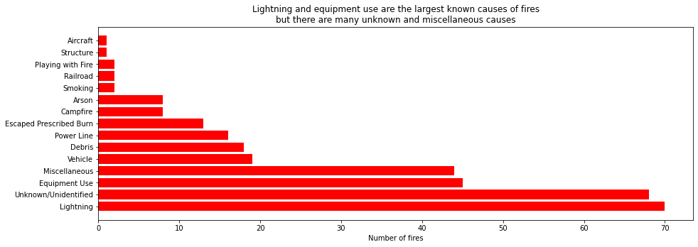

```python
# group by cause, count the numer of rows in each cause, reset the index and sort values by counts
bar_data = sdf_fires_2011.groupby(['CAUSE']).size().reset_index(name='counts').sort_values('counts', ascending = False)

# replace the non-descriptive integers with values from the metadata table so they are human readable
bar_data['CAUSE'] = bar_data['CAUSE'].replace([1.0, 2.0, 3.0, 4.0, 5.0, 6.0, 7.0, 8.0, 9.0, 10.0, 11.0, 12.0, 13.0, 14.0, 15.0, 16.0, 18.0],
                                              ['Lightning', 'Equipment Use', 'Smoking', 'Campfire', 'Debris', 'Railroad',
                                               'Arson', 'Playing with Fire', 'Miscellaneous', 'Vehicle', 'Power Line',
                                               'Firefighter Training', 'Non-Firefighter Training', 'Unknown/Unidentified',
                                              'Structure', 'Aircraft', 'Escaped Prescribed Burn'])

# set x and y for the bar plot
x = bar_data['CAUSE']
y = bar_data['counts']

# we will use matplotlib so we need to use magic command to plot the graph in the notebook
%matplotlib inline

# establish parameters for plot
plt.figure(figsize=(15,5))
plt.barh(x, y, color="red", tick_label = x)
plt.xlabel("Number of fires")
plt.title("Lightning and equipment use are the largest known causes of fires\nbut there are many unknown and miscellaneous causes")
plt.show()
```

This is really interesting, but we don't know if lightning is the cause of the *biggest* fires in California. This is an important relationship, so let's explore:

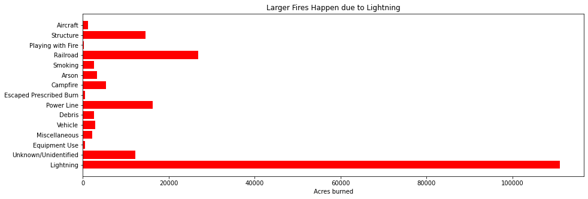

```python
x = bar_data['CAUSE'].unique() # get the causes
y = sdf_fires_2011.groupby(['CAUSE']).sum(['GIS_ACRES'])['GIS_ACRES'] # group by cause and collect the sum of acres burned for each

# establish plot parameters
plt.figure(figsize=(15,5))
plt.barh(x, y, color = 'red')
plt.xlabel("Acres burned")
plt.title("Larger Fires Happen due to Lightning")
plt.show()
```

So we know that the number acres burned due to lightning was much larger than for other causes, but this could be due to one large fire that is an outlier. Let's draw a histogram for the acres burned due to lightning.

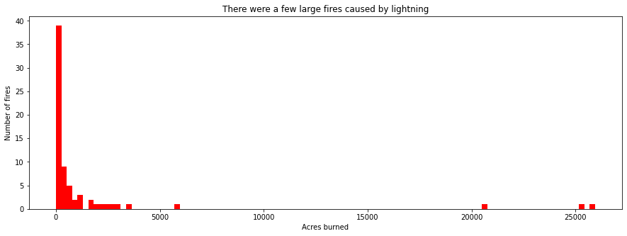

```python
x = sdf_fires_2011.query('CAUSE == 1.0')['GIS_ACRES']

plt.figure(figsize=(15,5))
plt.hist(x, bins = 100, color = 'red')
plt.xlabel("Acres burned")
plt.ylabel("Number of fires")
plt.title("There were a few large fires caused by lightning")
plt.show()
```

Now that we understand better *where* fires are happening, let's look at *when*.

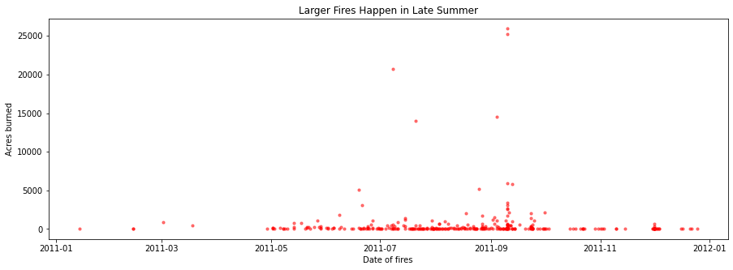

```python
x = sdf_fires_2011['ALARM_DATE'] # the date of the fire
y = sdf_fires_2011['GIS_ACRES'] # the acres burned

# set plot parameters
plt.figure(figsize=(15,5))
plt.scatter(x, y, s =10, c = 'red', alpha = .5)
plt.xlabel("Date of fires")
plt.ylabel("Acres burned")
plt.title("Larger Fires Happen in Late Summer")
plt.show()
```

Now I want to export my cleaned 2011 Spatial DataFrame as a feature class. I was having an issue with incompatible data types exporting to feature classes (objects and categories must be converted to strings), so I found an [Esrsi community solution](https://community.esri.com/t5/arcgis-api-for-python-questions/system-error-when-exporting-spatially-enabled/td-p/1044880) where someone was kind enough to write a function to fix the issue. I've used that function here. We love open source 😁

```python
# From Esri Community Solution:
def convert_dtypes_arcgis(df):
  # Convert dataframe dtypes which are not compatible with ArcGIS
  # Use builtin Pandas dtype conversion
  df = df.convert_dtypes(infer_objects=True)
  # Then str convert any remaining special object/category fields
  for col in df.columns:
    # print(col, '/', df[col].dtype)
    if df[col].dtype == 'object' or df[col].dtype == 'category':
      df[col] = df[col].astype('str')
  # Return modified df
  return df
```

```python
sdf_fires_2011 = sdf_fires_2011.replace(np.nan,0) # when we go to export this as a feature class, we cannot have any null values
sdf_fires_2011 = convert_dtypes_arcgis(sdf_fires_2011) # use the function above to convert all incompatible data types to strings!
```

```python
sdf_fires_2011.spatial.to_featureclass(location=r"C:/Users/IYOUNGS/Documents/ArcGIS/Projects/MyProject/MyProject.gdb/fires") # now I can export to feature class
arcpy.conversion.FeatureToRaster('fires', "GIS_ACRES", "fires_raster", 3650.70297840001) # convert to raster dataset!
```

Output

C:\Users\IYOUNGS\Documents\ArcGIS\Projects\MyProject\MyProject.gdb\fires_raster

Messages

Start Time: Wednesday, March 1, 2023 8:56:24 PM  
Succeeded at Wednesday, March 1, 2023 8:56:31 PM (Elapsed Time: 7.26 seconds)

## Land Use

Next I want to explore land uses. Land use data obtained from [USGS](https://www.usgs.gov/programs/gap-analysis-project/science/land-cover-data-download), titled: GAP/LANDFIRE National Terrestrial Ecosystems 2011. I want to understand which land use types are most common in zones that have burned. To do this, I used the [Zonal Statistics as Table](https://pro.arcgis.com/en/pro-app/latest/tool-reference/spatial-analyst/zonal-statistics-as-table.htm) tool in arcpy. First lets take a look at an image of the .tif because it cannot be mapped in a widget without a license.

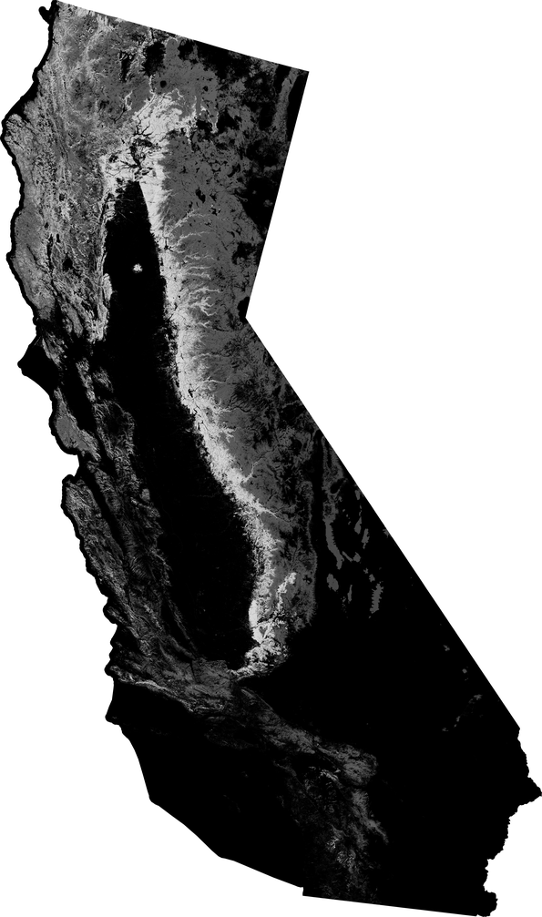

```python
# open the image
inv_img = Image.open(r'C:/Users/IYOUNGS/Downloads/gaplf2011lc_v30_CA/gaplf2011lc_v30_ca.tif', 'r').convert('RGB')
inv_img = inv_img.resize((595,1007),Image.ANTIALIAS) # resize it because it's very large
img = PIL.ImageOps.invert(inv_img) # invert the colors
display(img)
```

It shows us the variation in spectral imagery, but in order to get the values we have to load our .tif into a file geodatabase. Once that's done, we can use the raster as an input for the zonal statistics tool.

```python
# GAP/LANDFIRE National Terrestrial Ecosystems 2011 data in a fgdb
landuse = r'C:/Users/IYOUNGS/Documents/ArcGIS/Projects/MyProject/MyProject.gdb/gaplf2011lc_v30_ca'

# generate zonal statistics where the land use types are the zones
# the sum is the number of acres burned in the land use type
zonal_table = arcpy.ia.ZonalStatisticsAsTable(landuse, "VALUE", "fires_raster", "zonal_statistics", "DATA", "SUM")
```

To get a table in a file geodatabase into a Pandas DataFrame, I used this function from David Wasserman on [Github](https://gist.github.com/d-wasserman/e9c98be1d0caebc2935afecf0ba239a0)! 😁

```python
def arcgis_table_to_df(in_fc, input_fields=None, query=""):
    """Function will convert an arcgis table into a pandas dataframe with an object ID index, and the selected
    input fields using an arcpy.da.SearchCursor.
    :param - in_fc - input feature class or table to convert
    :param - input_fields - fields to input to a da search cursor for retrieval
    :param - query - sql query to grab appropriate values
    :returns - pandas.DataFrame"""
    OIDFieldName = arcpy.Describe(in_fc).OIDFieldName
    if input_fields:
        final_fields = [OIDFieldName] + input_fields
    else:
        final_fields = [field.name for field in arcpy.ListFields(in_fc)]
    data = [row for row in arcpy.da.SearchCursor(in_fc,final_fields,where_clause=query)]
    fc_dataframe = pd.DataFrame(data,columns=final_fields)
    fc_dataframe = fc_dataframe.set_index(OIDFieldName,drop=True)
    return fc_dataframe
```

```python
zonal = arcgis_table_to_df('zonal_statistics') # execute the function to convert the table to a Spatial DataFrame
zonal.sample(3)
```

| OBJECTID | VALUE | COUNT | AREA | SUM |
| --- | --- | --- | --- | --- |
| 10 | 484 | 1.0 | 1.332763e+07 | 5799.841 |
| 12 | 490 | 2.0 | 2.665526e+07 | 19815.698 |
| 5 | 181 | 2.0 | 2.665526e+07 | 41363.080 |

We will have to explore the metadata to figure out what the values correspond to. When I downloaded the .tif file, it came with a flat file with the corresponding values. Using Pandas, I'll pull that file out to look at it in a DataFrame.

```python
# use Pandas to read in table
tsv = pd.read_table(r'C:/Users/IYOUNGS/Downloads/gaplf2011lc_v30_CA/GAP_LANDFIRE_National_Terrestrial_Ecosystems_2011_Attributes.txt')
keys = tsv[['Value','ECOLSYS_LU']] # let's just look at the value-land use pairs
keys.sample(5)
```

|  | Value | ECOLSYS_LU |
| --- | --- | --- |
| 445 | 456 | Inter-Mountain Basins Alkaline Closed Depression |
| 110 | 111 | Southern Piedmont Dry Oak-(Pine) Forest |
| 219 | 225 | Mississippi River Bottomland Depression |
| 14 | 14 | East Gulf Coastal Plain Interior Upland Longle... |
| 95 | 95 | Appalachian Hemlock-Hardwood Forest |

What are the top ecosystems that burn by acreage?

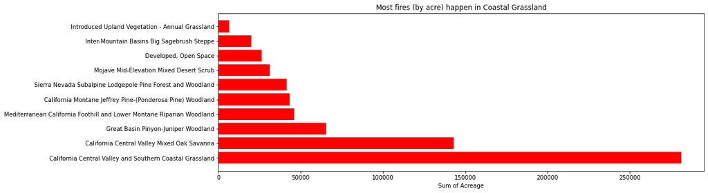

```python
zonal_keys = zonal.merge(keys, left_on='VALUE', right_on='Value', how = 'left') # merge the keys to the zonal statistics table

# sort the values by sum of acres burned and subset the top 10
top_area_burned = zonal_keys.sort_values('SUM', ascending = False)[:10].reset_index()

# set up parameters for the plot
x = top_area_burned['ECOLSYS_LU']
y = top_area_burned['SUM']

plt.figure(figsize=(15,5))
plt.barh(x, y, color = 'red')
plt.xlabel("Sum of Acreage")
plt.title("Most fires (by acre) happen in Coastal Grassland")
plt.show()
```

# Conclusion

Through this analysis, I learned a signficant amount about working with Spatial DataFrames, cleaning and exploring data in a Jupyter Notebook using Pandas, and how to plot with matplotlib. The project also revealed some interesting findings about where and when fires occurred in 2011. To end on a positive note, here is Baloo enjoying Lake Tahoe 😄🐕

[figure not shown]